# 使用Matplotlib绘图

## Getting Started with Matplotlib

A picture is worth a thousand words.

**Matplotlib** is a **Python package** for

- **2D** plotting that generates production-quality graphs.
- It supports interactive and non-interactive plotting,
- and can save images in several output formats (PNG, PS, and others).
- It can use multiple window toolkits (GTK+, wxWidgets, Qt, and so on)
- and it provides a wide variety of plot types (lines, bars, pie charts, histograms, and many more).
- In addition to this, it is highly customizable, flexible, and easy to use.

• The main web site at http://matplotlib.sourceforge.net/

Matplotlib was born in the **scientific area of computing**, where **gnuplot** and **MATLAB** were (and still are) used a lot.

Matplotlib was modeled on MATLAB, because graphing was something that MATLAB did very well.

- It uses Python
- It's open source, so no license to pay
- It's a real programming language (matlab & r)
- It's much more complete (a lot of python packages)
- It's very customizable and extensible
- It's integrated with LaTeX markup
- It's cross-platform and portable

### Flexibility

> With the entrance of Python into scientific toolboxes, an example of a workflow to process some data might be similar to this: "Write a Python script to parse data, then pass the data to a gnuplot script to plot it".

Now with Matplotlib, we can write a single script to parse and plot data, with a lot more flexibility (that gnuplot doesn't have) and consistently using the same programming language.

### Interactive

We have to think of plotting not just as the final step in working with our data, but as an important way of getting visual feedback during the process. Here, the interactive capabilities of Matplotlib will come and rescue us.

## Output formats

- Raster images: PNG, JPG, and BMP
  - DPI (dots-per-inch): Scaling operations such as zooming or resizing can result in a loss of quality, because the image contains only a limited amount of information.
- Vector images (descriptive format in the form of mathematical equations and geometrical primitives): EPS, PDF, PS, SVG
  - resolution-independent
  - PS or EPS formats are particularly useful for plots inclusion in LaTeX documents, the main scientific articles format since decades.

## Installing Matplotlib

Using packaged Python distributions (Anaconda python) that contain Matplotlib in the toolbox proposed

## Using Matplotlib

```python
# Using matplotlib
%matplotlib inline
# for jupyter
import matplotlib.pyplot as plt
```

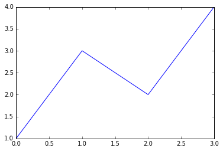

```python
plt.plot([1, 3, 2, 4])
plt.show()
```

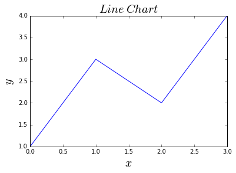

```python
plt.plot([1, 3, 2, 4])
plt.xlabel('$x$', fontsize = 20)
plt.ylabel('$y$', fontsize = 20)
plt.title('$Line\; Chart$', fontsize = 20)
plt.show()
```

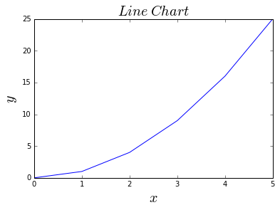

```python
x = range(6)
plt.plot(x, [xi**2 for xi in x])
plt.xlabel('$x$', fontsize = 20)
plt.ylabel('$y$', fontsize = 20)
plt.title('$Line\; Chart$', fontsize = 20)
plt.show()
```

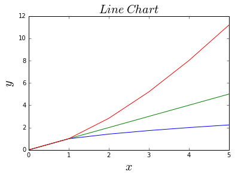

```python
x = range(6)
plt.plot(x, [xi**.5 for xi in x])
plt.plot(x, [xi for xi in x])
plt.plot(x, [xi**1.5 for xi in x])
plt.xlabel('$x$', fontsize = 20)
plt.ylabel('$y$', fontsize = 20)
plt.title('$Line\; Chart$', fontsize = 20)
plt.show()
```

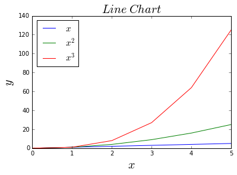

```python
x = range(6)
plt.plot(x, [xi for xi in x], label = '$x$')
plt.plot(x, [xi**2 for xi in x], label = '$x^2$')
plt.plot(x, [xi**3 for xi in x], label = '$x^3$')
plt.xlabel('$x$', fontsize = 20)
plt.ylabel('$y$', fontsize = 20)
plt.title('$Line\; Chart$', fontsize = 20)
plt.legend(loc=0,fontsize=15)
plt.show()
```

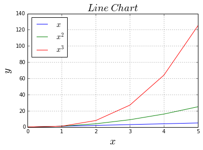

```python
x = range(6)
plt.plot(x, [xi for xi in x], label = '$x$')
plt.plot(x, [xi**2 for xi in x], label = '$x^2$')
plt.plot(x, [xi**3 for xi in x], label = '$x^3$')
plt.xlabel('$x$', fontsize = 20)
plt.ylabel('$y$', fontsize = 20)
plt.title('$Line\; Chart$', fontsize = 20)
plt.legend(loc=2,fontsize=15)
plt.grid(True)
plt.show()
```

```python
import numpy as np
x = np.array(range(6))
x*1.5
```

```
array([ 0. ,  1.5,  3. ,  4.5,  6. ,  7.5])
```

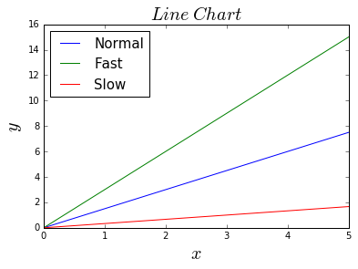

```python
plt.plot(x, x*1.5)
plt.plot(x, x*3.0)
plt.plot(x, x/3.0)
plt.legend(['Normal', 'Fast', 'Slow'],loc=2,fontsize=15)
plt.xlabel('$x$', fontsize = 20)
plt.ylabel('$y$', fontsize = 20)
plt.title('$Line\; Chart$', fontsize = 20)
plt.show()
```

- 0 best
- 1 upper right
- 2 upper left
- 3 lower left
- 4 lower right
- 5 right
- 6 center left
- 7 center right
- 8 lower center
- 9 upper center
- 10 center

```
(0.0, 5.0, 0.0, 8.0)
```

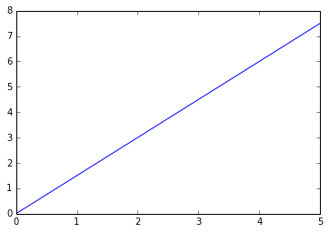

```python
plt.plot(x, x*1.5)
#plt.show()
plt.axis()
```

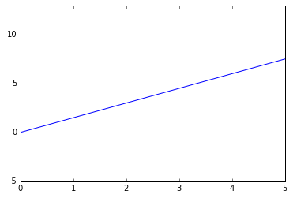

```python
plt.plot(x, x*1.5)
plt.axis([0, 5, -5, 13])
plt.show()
```

## Saving plots to a file

> plt.savefig('plot123.png')

```python
import matplotlib as mpl
mpl.rcParams['figure.figsize']
```

```
[6.0, 4.0]
```

```python
mpl.rcParams['savefig.dpi']
```

```
72.0
```

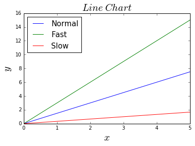

```python
plt.plot(x, x*1.5)
plt.plot(x, x*3.0)
plt.plot(x, x/3.0)
plt.legend(['Normal', 'Fast', 'Slow'],loc=2,fontsize=15)
plt.xlabel('$x$', fontsize = 20)
plt.ylabel('$y$', fontsize = 20)
plt.title('$Line\; Chart$', fontsize = 20)
plt.savefig('plot123_1.png', dpi=100)
plt.savefig('plot123_2.png', dpi=200)
plt.savefig('plot123_3.png', dpi=300)
```

```python
help(plt.savefig)
```

```
Help on function savefig in module matplotlib.pyplot:

savefig(*args, **kwargs)
    Save the current figure.

    Call signature::

      savefig(fname, dpi=None, facecolor='w', edgecolor='w',
              orientation='portrait', papertype=None, format=None,
              transparent=False, bbox_inches=None, pad_inches=0.1,
              frameon=None)

    The output formats available depend on the backend being used.

    Arguments:

      *fname*:
        A string containing a path to a filename, or a Python
        file-like object, or possibly some backend-dependent object
        such as :class:`~matplotlib.backends.backend_pdf.PdfPages`.

        If *format* is *None* and *fname* is a string, the output
        format is deduced from the extension of the filename. If
        the filename has no extension, the value of the rc parameter
        ``savefig.format`` is used.

        If *fname* is not a string, remember to specify *format* to
        ensure that the correct backend is used.

    Keyword arguments:

      *dpi*: [ *None* | ``scalar > 0`` | 'figure']
        The resolution in dots per inch.  If *None* it will default to
        the value ``savefig.dpi`` in the matplotlibrc file. If 'figure'
        it will set the dpi to be the value of the figure.

      *facecolor*, *edgecolor*:
        the colors of the figure rectangle

      *orientation*: [ 'landscape' | 'portrait' ]
```

[output cut: 22 more lines]

```
        figure background will be transparent.  If not provided, the
        rcParam 'savefig.frameon' will be used.

      *bbox_inches*:
        Bbox in inches. Only the given portion of the figure is
        saved. If 'tight', try to figure out the tight bbox of
        the figure.

      *pad_inches*:
        Amount of padding around the figure when bbox_inches is
        'tight'.

      *bbox_extra_artists*:
        A list of extra artists that will be considered when the
        tight bbox is calculated.
```

```python
mpl.rcParams['interactive']
```

```
True
```

## Control colors

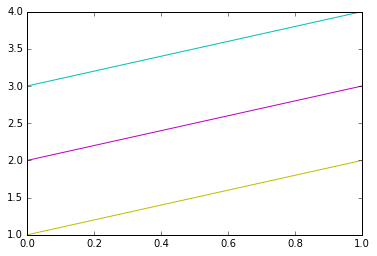

```python
import matplotlib.pyplot as plt
import numpy as np
y = np.arange(1, 3)
plt.plot(y, 'y');
plt.plot(y+1, 'm');
plt.plot(y+2, 'c');
plt.show()
```

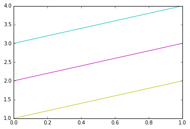

```python
plt.plot(y, 'y', y+1, 'm', y+2, 'c');
plt.show()
```

- b blue
- c cyan
- g green
- k black
- m magenta
- r red
- w white
- y yellow

### The other ways to specify colors

- The full color name, such as yellow, as specified in the Color name column of the previous table
- Hexadecimal string (the same format as in HTML code) such as #FF00FF
- RGB or RGBA tuples, for example, (1, 0, 1, 1)
- Grayscale intensity, in string format such as '0.7'

## Control line styles

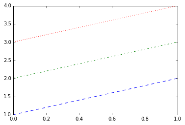

```python
plt.plot(y, '--', y+1, '-.', y+2, ':');
plt.show()
```

- **-** solid line
- -- dashed line
- -. dash-dot line
- : dotted line

## Control marker styles

s Square marker p Pentagon marker `*` Star marker h Hexagon marker H Rotated hexagon marker `+` Plus marker x Cross (x) marker D Diamond marker d Thin diamond marker | Vertical line (vline symbol) marker `-` Horizontal line (hline symbol) marker

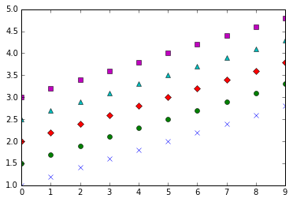

```python
y = np.arange(1, 3, 0.2)
plt.plot(y, 'x', y+0.5, 'o', y+1, 'D', y+1.5, '^', y+2, 's');
plt.show()
```

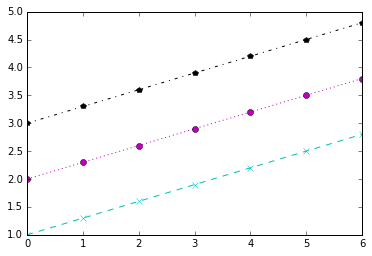

```python
y = np.arange(1, 3, 0.3)
plt.plot(y, 'cx--', y+1, 'mo:', y+2, 'kp-.');
plt.show()
```

- color or c
- linestyle
- linewidth
- marker
- markeredgecolor
- markeredgewidth
- markerfacecolor
- markersize

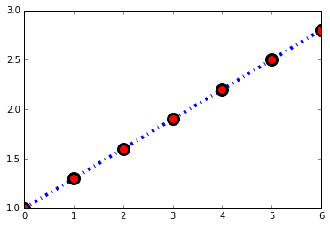

```python
y = np.arange(1, 3, 0.3)
plt.plot(y, color='blue', linestyle='dashdot', linewidth=4,
   marker='o', markerfacecolor='red', markeredgecolor='black',
   markeredgewidth=3, markersize=12);
plt.show()
```

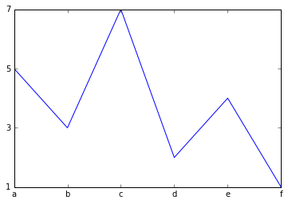

```python
x = [5, 3, 7, 2, 4, 1]
plt.plot(x)
plt.xticks(range(len(x)), ['a', 'b', 'c', 'd', 'e', 'f'])
plt.yticks(range(1, 8, 2))
plt.show()
```

# Histogram charts

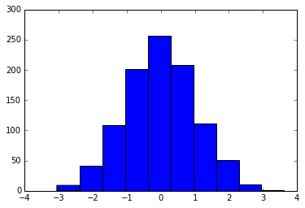

```python
y = np.random.randn(1000)
plt.hist(y)
plt.show()
```

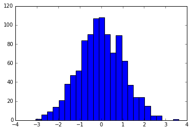

```python
plt.hist(y, 25);
plt.show()
```

# Error bar charts

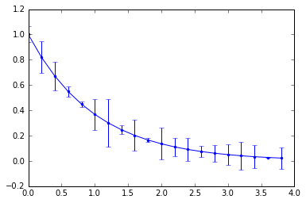

```python
x = np.arange(0, 4, 0.2)
y = np.exp(-x)
e1 = 0.1 * np.abs(np.random.randn(len(y)))
plt.errorbar(x, y, yerr=e1, fmt='.-');
plt.show()
```

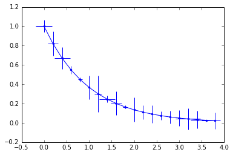

```python
# specify both yerr and xerr together:
e2 = 0.1 * np.abs(np.random.randn(len(y)))
plt.errorbar(x, y, yerr=e1, xerr=e2, fmt='.-', capsize=0);
plt.show()
```

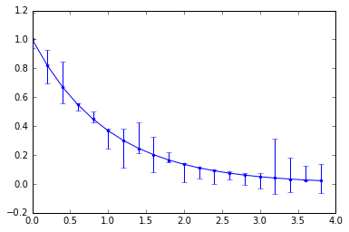

```python
plt.errorbar(x, y, yerr=[e1, e2], fmt='.-');
plt.show()
```

# Bar charts

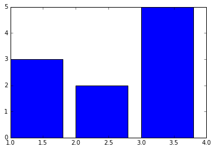

```python
plt.bar([1, 2, 3], [3, 2, 5]);
plt.show()
```

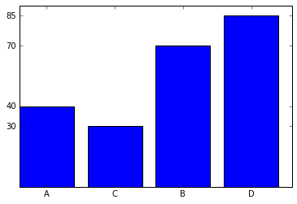

```python
dict = {'A': 40, 'B': 70, 'C': 30, 'D': 85}
for i, key in enumerate(dict): plt.bar(i, dict[key]);
plt.xticks(np.arange(len(dict))+0.4, dict.keys());
plt.yticks(dict.values());
plt.show()
```

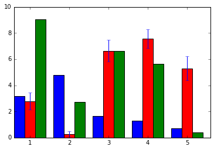

```python
data1 = 10*np.random.rand(5)
data2 = 10*np.random.rand(5)
data3 = 10*np.random.rand(5)
e2 = 0.5 * np.abs(np.random.randn(len(data2)))
locs = np.arange(1, len(data1)+1)
width = 0.27
plt.bar(locs, data1, width=width);
plt.bar(locs+width, data2, yerr=e2, width=width,
   color='red');
plt.bar(locs+2*width, data3, width=width, color='green') ;
plt.xticks(locs + width*1.5, locs);
plt.show()
```

# Pie charts

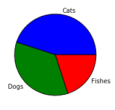

```python
plt.figure(figsize=(3,3));
x = [45, 35, 20]
labels = ['Cats', 'Dogs', 'Fishes']
plt.pie(x, labels=labels);
plt.show()
```

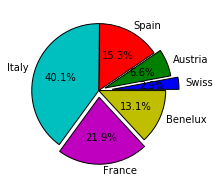

```python
plt.figure(figsize=(3,3));
x = [4, 9, 21, 55, 30, 18]
labels = ['Swiss', 'Austria', 'Spain', 'Italy', 'France',
   'Benelux']
explode = [0.2, 0.1, 0, 0, 0.1, 0]
plt.pie(x, labels=labels, explode=explode, autopct='%1.1f%%');
plt.show()
```

# Scatter plots

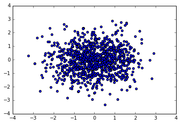

```python
x = np.random.randn(1000)
y = np.random.randn(1000)
plt.scatter(x, y);
plt.show()
```

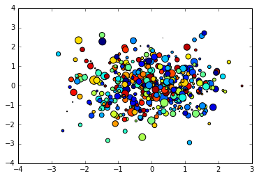

```python
size = 50*np.random.randn(1000)
colors = np.random.rand(1000)
plt.scatter(x, y, s=size, c=colors);
plt.show()
```

# Polar charts

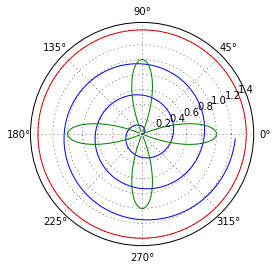

```python
theta = np.arange(0., 2., 1./180.)*np.pi
plt.polar(3*theta, theta/5);
plt.polar(theta, np.cos(4*theta));
plt.polar(theta, [1.4]*len(theta));
plt.show()
```

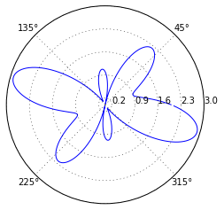

```python
theta = np.arange(0., 2., 1./180.)*np.pi
r = np.abs(np.sin(5*theta) - 2.*np.cos(theta))
plt.polar(theta, r);
plt.thetagrids(range(45, 360, 90));
plt.rgrids(np.arange(0.2, 3.1, .7), angle=0);
plt.show()
```

# Text inside figure

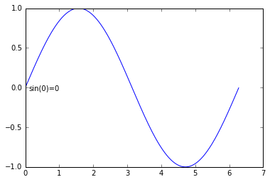

```python
x = np.arange(0, 2*np.pi, .01)
y = np.sin(x)
plt.plot(x, y);
plt.text(0.1, -0.04, 'sin(0)=0');
plt.show()
```